# Project 1: The Class

# Background

The following analysis examines the 114 survey responses from our EDAV class.

# Waitlist

- 16% of the class started on the waitlist.

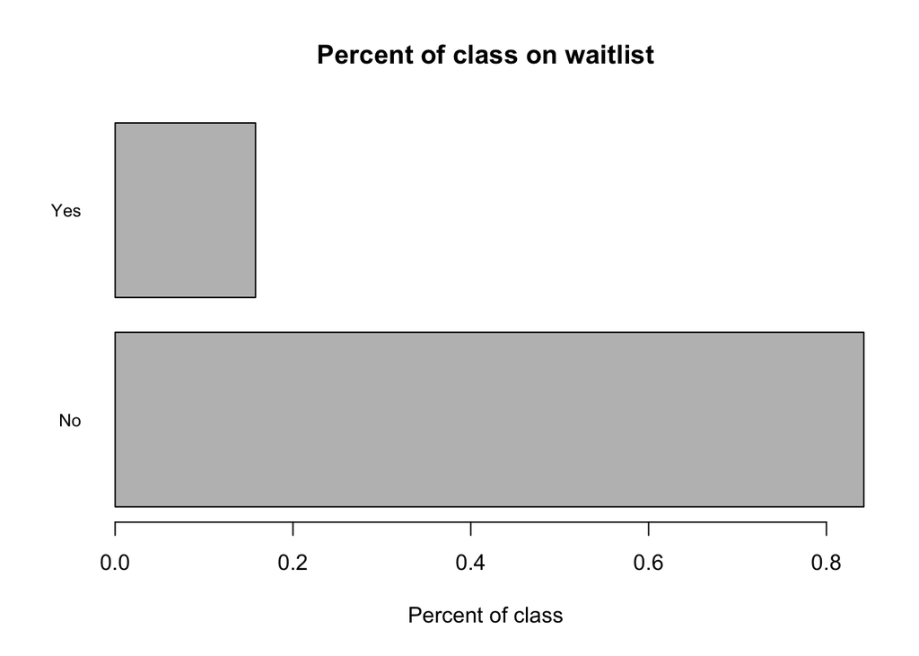

# Gender

- 71% of the class is male, 28% female, and 1% says their gender doesn’t matter.

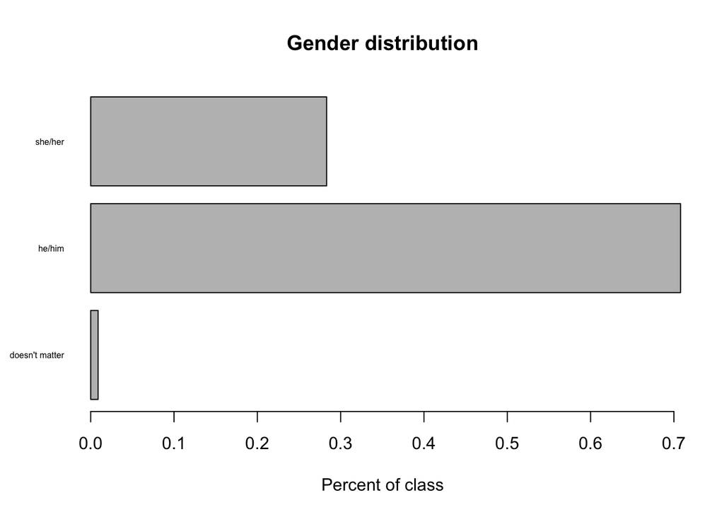

# Program

# Tools

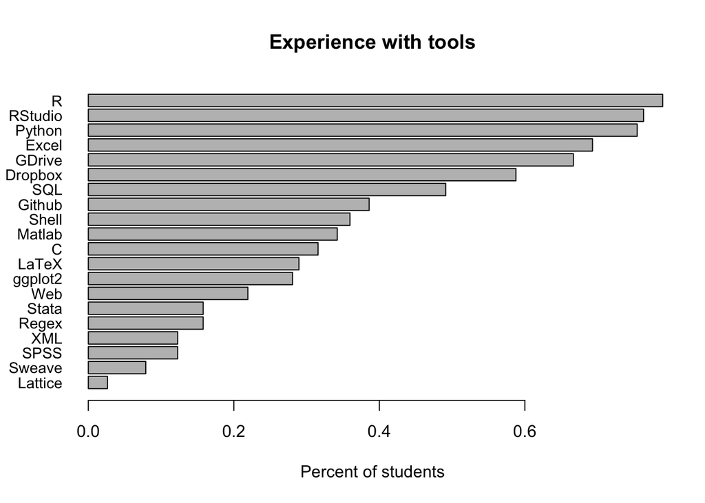

## Hierarchical clustering reveals distinct clusters of tool usage

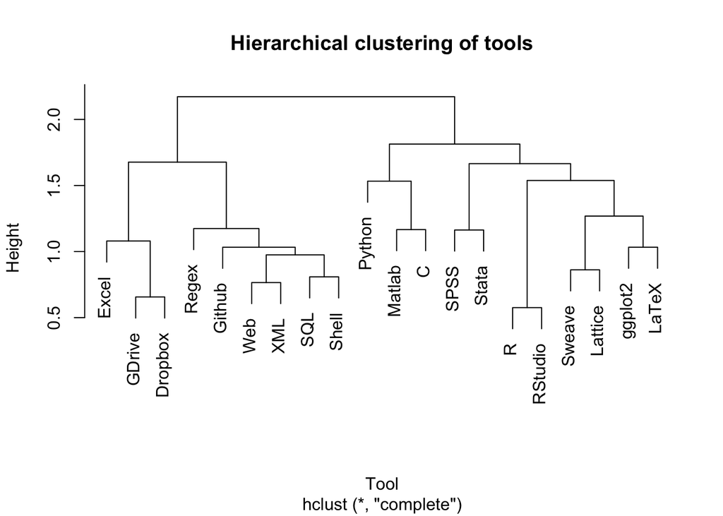

### We interpret these clusters as:

- Excel & productivity tools
- Engineering tools
- Miscellaneous languages
- R and R packages

#### A correlation plot reveals the granular relationships between tools:

- There are some competitive products that are positively correlated while others are negatively correlated. For instance: dropbox and google drive are positively correlated while R and Python are negatively correlated. Perhaps it’s because dropbox and google drive have similar usability while R and Python are less interchangeable.

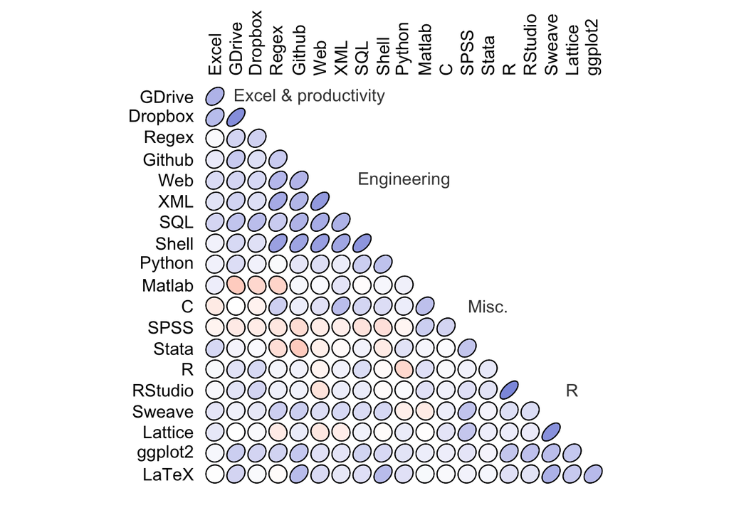

# Text editors

- The distribution of text editor shows that RStudio is heavily favored.

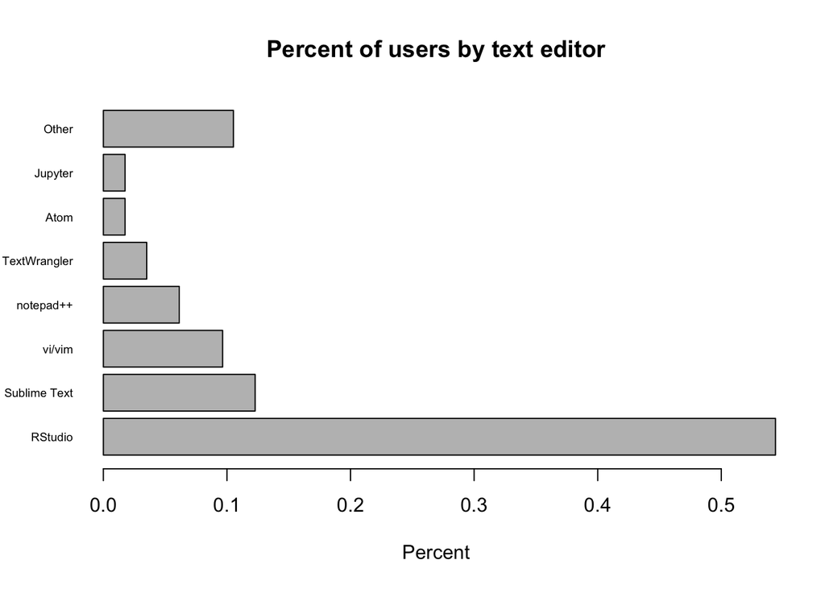

- The sankey chart shows that the preference for RStudio is explained by the large number of statistic and data-science masters students.
- We can see text editor preferences by program: few students of statistics prefer different editors while 40% of data-science students do not use RStudio.

[interactive chart not shown]

# Experience by tool

# Tool expertise by program

- Data Science Certification students tend to have the highest proportion of students with no experience with each tool, but they are pretty good at using Github.
- Most other programs are familiar with skills in R.
- Among all these six tools, experts are minority. Statistics major has the highest proportion of experts.

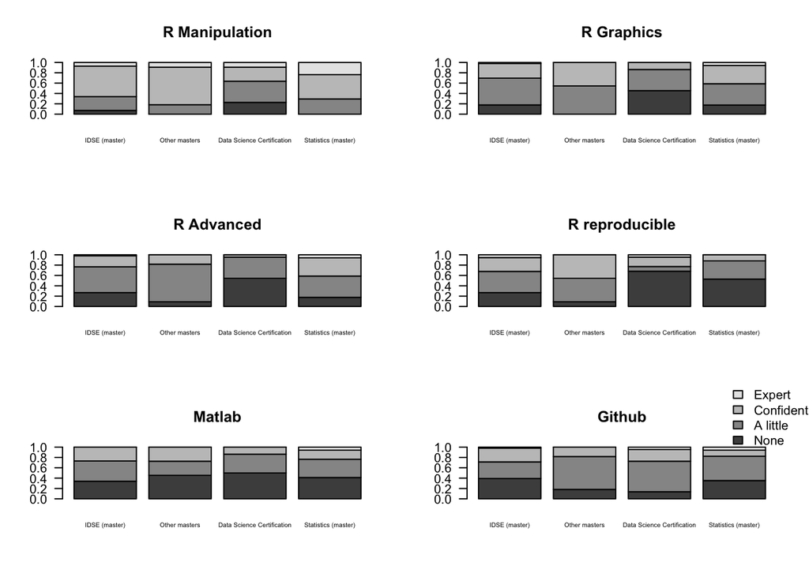

[interactive chart not shown]